# R筆記 – (13) 網路爬蟲(Crawler)：用xml2爬美國中情局(CIA)的解密文件資料庫

skydome20

2017/01/31

[返回主目錄](https://rpubs.com/skydome20/Table)

# 本篇目錄

0. 前言
1. 解析CIA (CREST project)的網址
2. 用xml2解析CIA搜尋結果的資訊
   - (1) 解密文件的「標題」和對應的「超連結」
   - (2) 共有「多少」搜尋結果
   - (3) 共有「幾頁」搜尋結果
3. 下載解密文件
4. 進階：自動化整個流程(成果展現)
   - basic.info.query.CIA_CREST(query)
   - parsing.pages.CIA_CREST(query, pages)
   - download.doc.CIA_CREST(parse.table)
5. 總結
6. Reference

# **0. 前言**

> (本篇筆記適合對網路爬蟲有一定概念的人；若不懂相關知識，最後的Reference有提供一些學習資源，請先看過後再來閱讀。)

> 本篇筆記的[程式碼已經在Github上釋出。](https://github.com/skydome20/crawler_CIA_CREST)

2017/01/18，美國中央情報局(CIA)做出一件讓全世界驚奇的事情，就是把93萬份解密文件釋出到官網上，供社會大眾自由下載查閱。此事立刻讓各國媒體相繼報導：

- [真正《X 檔案》解密！美國中情局 CIA 的 90 萬份上網公開解密](http://technews.tw/2017/01/23/x-files-from-cia/)
- [CIA解密93萬筆文件：幽浮、超能力、「共軍解放台灣」都是真的](https://www.thenewslens.com/article/59790)
- [CIA解密檔案 7萬份中國情報曝光](http://www.ntdtv.com/xtr/b5/2017/01/20/a1307779.html)
- [The Best of the CIA’s 12-Million Page CREST Archive](https://www.wired.com/2017/01/ufos-psychics-spies-cia-just-put-12m-pages-files-online-start/)

此項專案名為CREST(the CIA Record Search Tool；「中情局記錄搜尋工具」)。從[官網](https://www.cia.gov/library/readingroom/collection/crest-25-year-program-archive)進去後，會看見這樣的畫面：

[figure not shown]

本來，民眾得前往美國馬里蘭州（Maryland的國家檔案館)，使用裡面特定的4台電腦上才能查詢；

不過現在大家都可以自由上網，輸入關鍵字，並且下載相關的解密文件。

例如，當輸入「**Kennedy**」(甘迺迪)時，跑出的結果如下：

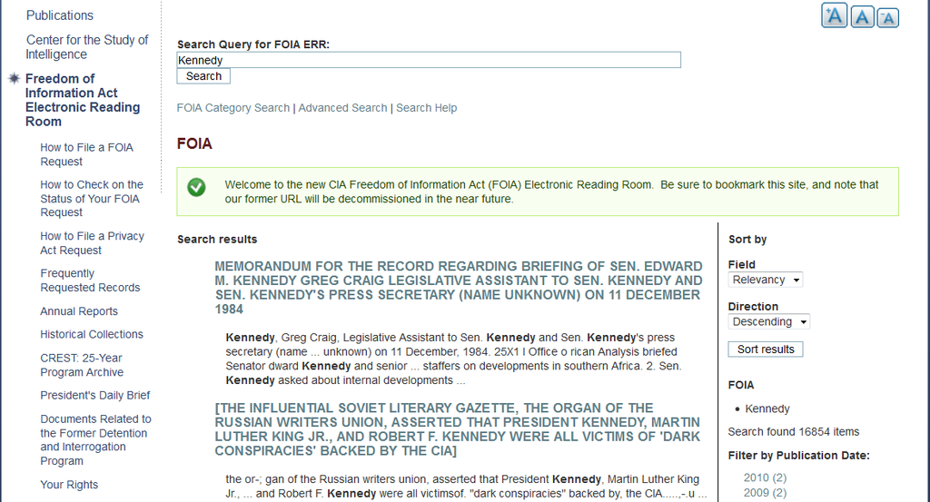

點擊第一個結果，可以有更詳細的資訊，以及該文件的pdf下載點：

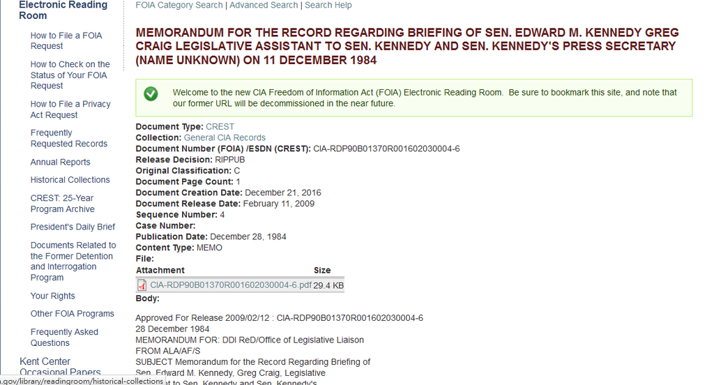

在玩賞一番(?)這項服務後，發現裡面不少資料都相當有趣。

然而，由於資料庫太過龐大，光是用人眼看完每一篇文件的標題，就得花上不少時間；若是要下載大量的解密文件，一篇一篇點進去下載，感覺是一個很蠢的方法。

因此，我就萌生了一個想法：**何不用R寫一個網路爬蟲？**

一個用來爬CIA網站、可以很快知道所有文章標題、協助下載大量解密文件的網路爬蟲(Web Crawler)，應該會很酷吧？

於是，這篇筆記就誕生了！

# **1. 解析CIA (CREST project)的網址**

在輸入關鍵字搜尋解密文件時，CIA的網站有一個很明顯的改變：

(搜尋**Kennedy**前的網址：https://www.cia.gov/library/readingroom/collection/crest-25-year-program-archive)

(搜尋**Kennedy**後的網址：https://www.cia.gov/library/readingroom/search/site/Kennedy)

[figure not shown]

然而，一個頁面不可能呈現出所有的結果；

因此當看下一頁的結果時，會發現網址後面又增加了一些數字(第一頁對應的是page=0，第二頁page=1…以此類推)：

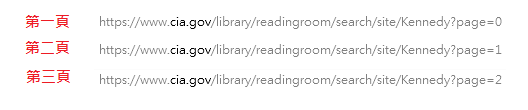

因此根據以上觀察的結果，我們可以得知CIA搜尋結果的網址型態如下：

```r
https://www.cia.gov/library/readingroom/search/site/關鍵字?page=頁碼
```

其中，「**關鍵字**」是我們所輸入的；而「**頁碼**」是對應的結果頁數，從0開始。

換句話說，這樣的型態可以讓我們寫一個程式，自動回傳結果的網址：

```r
# Parameters Settings
query = 'Kennedy'    # keyword for query
pages = c(0,9,19)    # pages where you want to search

# basic CIA (CREST project) URL: 'https://www.cia.gov/library/readingroom/search/site/'
result.urls = paste('https://www.cia.gov/library/readingroom/search/site/',
                     paste(query, paste('page=', pages, sep=''), sep='?'),
                     sep='')
result.urls
```

```
## [1] "https://www.cia.gov/library/readingroom/search/site/Kennedy?page=0"
## [2] "https://www.cia.gov/library/readingroom/search/site/Kennedy?page=9"
## [3] "https://www.cia.gov/library/readingroom/search/site/Kennedy?page=19"
```

(上面範例回傳的網址是：搜尋**Kennedy**後，第**1, 10, 20**頁的結果網址。若有興趣，可以用瀏覽器打開來看看)

這個程式只要在一開始設定好參數(**query, pages**)，就可以回傳對應的結果網址。

而下一步，就是用xml2來分析這些結果網址。

# **2. 用xml2解析CIA搜尋結果的資訊**

有了結果網址後，我們可以用瀏覽器(browser)打開，觀察CIA結果的網頁中，有哪些資訊可能是我們需要的：

```r
# Now we take the first result url to observe the infromation on this website
result.urls[1]
```

```
## [1] "https://www.cia.gov/library/readingroom/search/site/Kennedy?page=0"
```

當用瀏覽器打開結果網址以後，會呈現出下面的結果，並標示出其中我所需要的資訊：

**1. 每個解密文件的「標題」和對應的「超連結」。**  
**2. 共有「多少」的搜尋結果。**  
**3. 共有「幾頁」搜尋結果。**

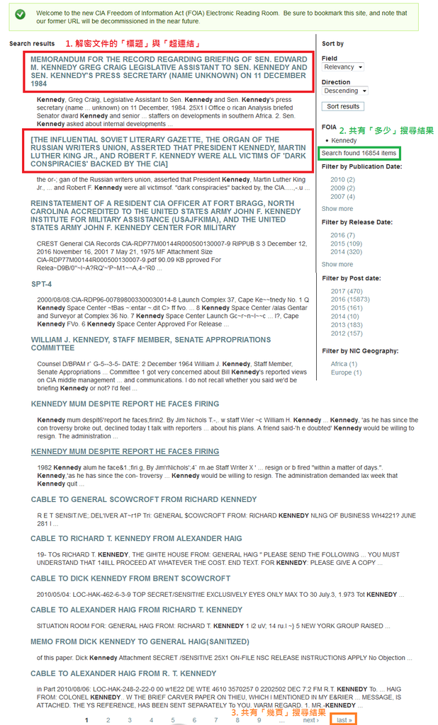

要得到以上三點資訊，我們要查看網頁的html原始碼，方法是按**F12**，便會在瀏覽器上出現一個「檢測器」。

(我以Firefox為例, 而Chrome也適用)：

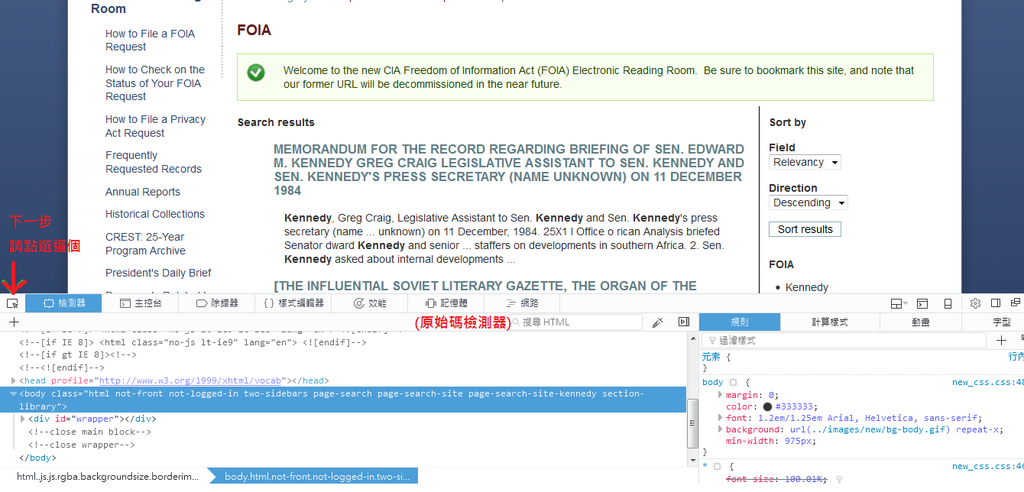

在左上角有一個「檢測頁面中元素」的按鈕，可以協助判斷網頁中每個元素所對應的原始碼是哪些。

### **(1) 解密文件的「標題」和對應的「超連結」。**

將滑鼠移動到解密文件的標題時，會出現下面這個現象：

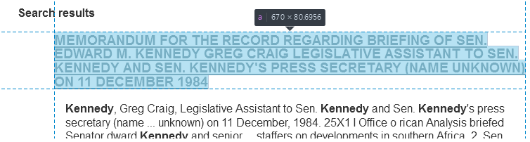

對應的html碼則會顯示在「檢測器」中：

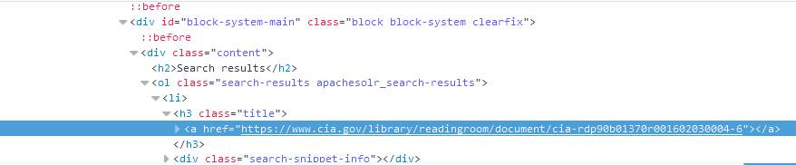

有了上面的資訊，便可以撰寫程式碼。使用的套件是`xml2`，主要會用到下面這些函式：

- read_html()：將網址所對應的html頁面，儲存成一個物件。
- xml_find_all()：找到符合「規則」的所有html原始碼。
- xml_text()：從html原始碼中，萃取「內容」的資訊。
- xml_attr()：從html原始碼中，萃取「屬性」的資訊。

(若看不懂以下的程式碼，請先參考頁底的Reference，或是閱讀[投影片p.13~p.18](http://www.slideshare.net/tw_dsconf/r-64232974)。)

```r
require(xml2)
# 讀取url，將html頁面儲存成一個物件
html.page = read_html(url(result.urls[1]))
# 根據上圖的資訊，寫一個xpath
xpath = "//*[@class='search-results apachesolr_search-results']/li/h3/a"
target = xml_find_all(html.page, xpath)
# 解密文件的「標題」
title = xml_text(target)
# 解密文件的「超連結」
download.url = unlist(xml_attr(target, "href"))
# 最後，將這頁的資訊儲存成一個data frame
page.info = data.frame(title=title, url=download.url, stringsAsFactors = F)
tail(page.info)
```

```
##                                                title
## 15         MEMO TO COLONEL KENNEDY FROM GENERAL HAIG
## 16  CABLE TO BRENT SCOWCROFT FROM RICHARD T. KENNEDY
## 17       CABLE TO BRENT SCOWCROFT FROM R. T. KENNEDY
## 18        CABLE TO DICK KENNEDY FROM BRENT SCOWCROFT
## 19   CABLE TO ALEXANDER HAIG FROM RICHARD T. KENNEDY
## 20 MEMO FROM DICK KENNEDY TO GENERAL HAIG(SANITIZED)
##                                                                    url
## 15   https://www.cia.gov/library/readingroom/document/loc-hak-8-4-31-4
## 16 https://www.cia.gov/library/readingroom/document/loc-hak-505-8-33-6
## 17  https://www.cia.gov/library/readingroom/document/loc-hak-505-7-8-5
## 18  https://www.cia.gov/library/readingroom/document/loc-hak-462-6-3-9
## 19  https://www.cia.gov/library/readingroom/document/loc-hak-461-6-3-0
## 20 https://www.cia.gov/library/readingroom/document/loc-hak-173-5-13-0
```

### **(2) 共有「多少」搜尋結果**

將滑鼠移動到呈現多少筆搜尋結果的元素上時，會出現下面這個現象：

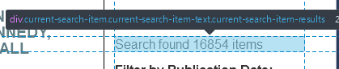

對應的html碼則會顯示在「檢測器」中：

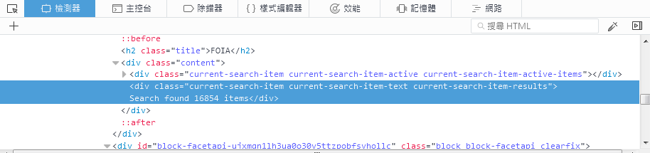

```r
require(xml2)
html.page = read_html(url(result.urls[1]))

# find nodes which match the 'pattern' of xpath
xpath = "//*[@class='current-search-item current-search-item-text current-search-item-results']"
target = xml_find_all(html.page, xpath)

# the result of search items
xml_text(target)
```

```
## [1] "Search found 16855 items"
```

### **(3) 共有「幾頁」搜尋結果**

對應的html碼則會顯示在「檢測器」中：

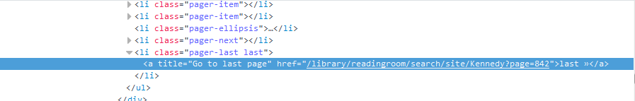

```r
require(xml2)
html.page = read_html(url(result.urls[1]))

# find nodes which match the 'pattern' of xpath
xpath = "//*[@class='pager-last last']/a"
target = xml_find_all(html.page, xpath)

# last page url
last.page.url = xml_attr(xml_find_all(html.page, xpath), "href")
last.page.url
```

```
## [1] "/library/readingroom/search/site/Kennedy?page=842"
```

```r
# last page number
strsplit(last.page.url, split="page=")[[1]][2]
```

```
## [1] "842"
```

# **3. 下載解密文件**

上一步，我們每一個解密文件的「標題」與「超連結」，接下來就是如何用R來下載這些解密文件。

用滑鼠點擊第一個解密文件的標題，會出現像這樣的畫面：

[figure not shown]

用和前面一樣的手法，知道下載網址所對應的html：

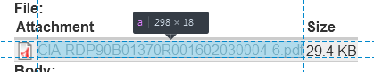

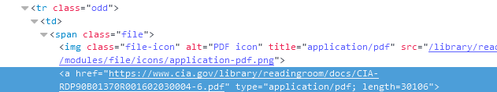

於是，根據「超連結」，我們先讀取下載頁面的html，然後用xpath找出對應的下載連結：

```r
require(xml2)
# 先跳到第一個解密文件的下載頁面
html.page = read_html(url(page.info$url[1]))

# 然後用xpath分析
xpath = "//*[@class='odd']/td/span/a"
target = xml_find_all(html.page, xpath)

# 找出下載連結
doc.url = as.character(unlist(xml_attr(target, "href")))
doc.url
```

```
## [1] "https://www.cia.gov/library/readingroom/docs/CIA-RDP90B01370R001602030004-6.pdf"
```

```r
# 然後下載成一個名為'1_CIA_file.pdf'的檔案
download.file(doc.url, '1_CIA_file.pdf', method='auto', mode='wb')
```

**(注意，使用`download.file()`時，參數`mode='wb'`一定要這樣設定，否則下載的文件會有錯誤)**

最後，打開的PDF檔案就會像這樣：

[figure not shown]

# **4. 進階：自動化整個流程(成果展現)**

前面1~3章的重點，主要著重在如何用R來解析CIA的網站，實作出一些基本的程式碼。

但若要達到**彈性且自動化**下載所有文件，單單這樣是不足的。

因此我進一步強化前面提及的程式碼，寫成各自功能的function，發表在Github上。

[Github下載點在這裡](https://github.com/skydome20/crawler_CIA_CREST)，其中：

1. `crawler_CIA_CREST.R`：主要有3個functions。
2. `main.R`： 執行的主要程式。

下載好以後，在`crawler_CIA_CREST.R`裡面有3個functions：

1. `basic.info.query.CIA_CREST(query)`：參數是關鍵字，回傳初步的搜尋結果。
2. `parsing.pages.CIA_CREST(query, pages)`：參數是關鍵字和指定頁碼，回傳parse.table。
3. `download.doc.CIA_CREST(parse.table)` ：參數是parse.table，自動下載解密文件到相關路徑(relative path)，回傳對照表(標題-檔名)。

打開main.R時，你會發現裡面已經有一些範例(examples)。

下面會詳加解釋、示範這三個functions的功能。

先匯入`crawler_CIA_CREST.R`

```r
source("crawler_CIA_CREST.R")
```

## basic.info.query.CIA_CREST(query)

這個函式會初步解析搜尋結果的頁面，顯示相關資訊出來，讓使用者能夠先得知自己想要查詢關鍵字的資訊。

```r
# Give a query
basic.info.query.CIA_CREST(query = "UFO")
```

```
## The search query is for CIA Freedom of Information Act (FOIA) Electronic Reading Room (ERR)
## URL: https://www.cia.gov/library/readingroom/collection/crest-25-year-program-archive
##
## Your query is : UFO
## Search found 1729 items
## The results contain 0 ~ 86 pages
```

```r
# Give a query
basic.info.query.CIA_CREST(query = "Kennedy")
```

```
## The search query is for CIA Freedom of Information Act (FOIA) Electronic Reading Room (ERR)
## URL: https://www.cia.gov/library/readingroom/collection/crest-25-year-program-archive
##
## Your query is : Kennedy
## Search found 16855 items
## The results contain 0 ~ 842 pages
```

有了上面的資訊後，我們就知道要搜尋的主題中，頁碼的限制範圍是多少(例如，Kennedy是0~842頁)。

## parsing.pages.CIA_CREST(query, pages)

考量到有時候並不需要下載「所有」的解密文件，或許只要「前十頁」的解密文件就好。

因此，我在這個函式添加**pages**的參數，讓使用者可以給定頁碼。

由上面的資訊，我們知道「Kennedy」的結果是 0 ~ 842 頁，是為了讓使用者知道頁碼的限制範圍，避免在給定頁碼時超出範圍。

假使，現在我們只需要「Kennedy」這個主題「前十頁」的搜尋結果，那就可以先設定好參數：

```r
your.query = 'Kennedy'
page.nums = c(0:9)     # top 10 pages

# return a parse.table
parse.table = parsing.pages.CIA_CREST(your.query, page.nums)
```

```
## Success to return a parse.table
```

最後，這個函式會回傳一個parse.table，具有四個欄位：

1. title : 解密文件的「標題」。
2. download.url : 對應「超連結」。
3. page : 所在的「頁碼」。
4. correspond.page : 所在的「頁面網址」。

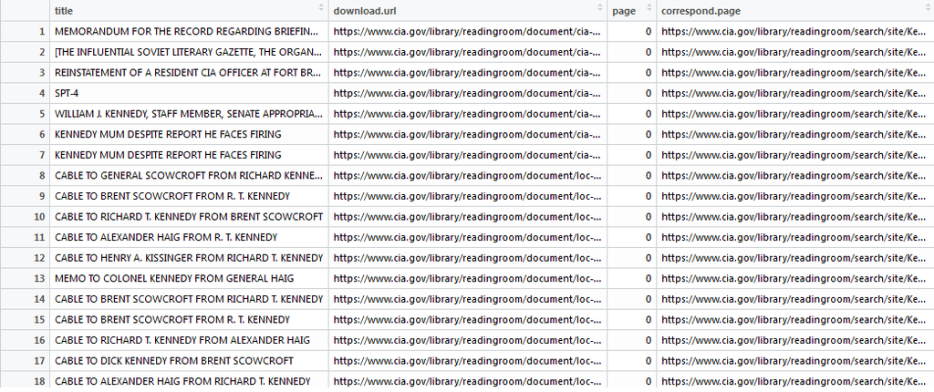

這個parse.table所包含的，就是「Kennedy」這個主題「前十頁」的所有搜尋結果。

如果想要下載這些解密文件，那就要用到最後一個函式。

## download.doc.CIA_CREST(parse.table)

將上一個函式回傳的parse.table，當作參數，這個函式會自動開始下載所有的解密文件(.pdf)到相對路徑的資料夾內。

```r
# download files according to the parse.table from parsing.pages.CIA_CREST()
# and return a reference.table
referece.table = download.doc.CIA_CREST(parse.table)
```

注意的是，這裡會回傳一個對照表，因為下載的pdf檔名是CIA編碼的命名；對照表可以協助對應解密文件的「標題」，避免因編碼的命名而無從得知文件的主題。

[figure not shown]

最後，程式碼會像這樣(main.R)：

```r
# This is a example for downloading CIA files of 'Kennedy' in top 10 pages

   source("crawler_CIA_CREST.R")

#=== 1. Give a query to get basic information ===#
   basic.info.query.CIA_CREST(query = "Kennedy")

#=== 2. Parse results according to given query and pages ===#
   your.query = 'Kennedy'
   page.nums = c(0:9)    # top 10 pages
   # return a parse.table
   parse.table = parsing.pages.CIA_CREST(your.query, page.nums)

#=== 3. Auto-download files according to the parse.table ===#
   # download files according to the parse.table from parsing.pages.CIA_CREST()
   # and return a reference.table
   reference.table = download.doc.CIA_CREST(parse.table)
```

[(程式碼皆發表在Github)](https://github.com/skydome20/crawler_CIA_CREST)

# **總結**

作為資料科學家，有時候要自己去蒐集資料，網路爬蟲是常用的手法之一。

平常可以看到python, java爬蟲的文章，卻鮮少看見用R實作一個系統性的網路爬蟲程式。

剛好這次CIA解密文件的新聞頗為有趣，我本身又滿喜歡R的，於是就寫出這篇筆記，希望有所幫助。

值得一提的是，這次使用的套件是**`xml2`**，但有更多人傾向使用**`rvest`**來爬蟲。(因此網路上**`rvest`**的文章比**`xml2`**還多，要學習的話會更為容易)

兩者的基本觀念是一模一樣的，只是寫法會不太一樣。

It’s still a long way to go~

# **Reference**

- 大數學堂 : [什麼是網路爬蟲?](http://www.largitdata.com/course/1/)
- [什麼是xpath？](https://zh.wikipedia.org/zh-tw/XPath)
- [手把手教你 R 語言資料分析實務](http://www.slideshare.net/tw_dsconf/r-64232974)
- [Parse and process XML (and HTML) with xml2](https://blog.rstudio.org/2015/04/21/xml2/)
- [crawler_CIA_CREST (on Github)](https://github.com/skydome20/crawler_CIA_CREST)